# ¿Son insulares las provincias italianas? Una extensión espacial al multiplicador fiscal de Acconcia, Corsetti y Simonelli (2014)

AUTORES

Paula (pau)

Fernando (fer)

Mateo (teo)

# 1 Resumen

Este trabajo replica y extiende espacialmente a Acconcia et al. (2014), quienes estiman el multiplicador fiscal de la inversión pública en las provincias italianas instrumentando el gasto con las disoluciones de concejos municipales por infiltración mafiosa (Ley 164/1991). Nuestra replicación reproduce con precisión los resultados originales sobre el panel de 95 provincias y 950 observaciones (1990–1999): multiplicador de impacto de 1.55, dinámico a dos años de 1.30 y acumulado de 1.96, con un estadístico F de instrumento débil de 12.8. La extensión consiste en someter a escrutinio espacial formal la afirmación de los autores de que las economías provinciales italianas son “insulares” —conclusión que ellos derivan de un procedimiento simple, añadir el gasto regional agregado como regresor adicional. Definimos matrices de pesos basadas en proximidad geográfica, contrastamos la dependencia espacial mediante tests LM, estimamos las especificaciones SAR, SEM y SDM, calculamos los efectos directos, indirectos y totales en el sentido de LeSage y Pace (2009), y empleamos un estimador GMM espacial (`splm::spgm`) que corrige simultáneamente dependencia espacial y endogeneidad —algo que la estimación por máxima verosimilitud no permite. Los resultados confirman la existencia de dependencia espacial significativa en el crecimiento provincial —presente tanto en la variable dependiente como en los errores— pero no revelan un canal de transmisión del gasto público entre provincias vecinas: la insularidad postulada por el paper original resiste el escrutinio. Complementamos el análisis con un ejercicio de heterogeneidad por macrorregión que valida el diseño de identificación, un balance test de pre-trends y verificaciones de robustez frente a cuatro matrices de pesos alternativas.

# 2 Introducción

La medición del multiplicador fiscal es una de las preguntas más discutidas y menos consensuadas de la macroeconomía aplicada (Auerbach y Gorodnichenko, 2012; Ilzetzki et al., 2013; Ramey, 2011). Buena parte de la disputa se explica por la endogeneidad del gasto: los gobiernos ajustan sus decisiones de inversión en respuesta al ciclo económico, de modo que la asociación observada entre gasto y actividad económica confunde causalidad con reacción anticíclica (Blanchard y Perotti, 2002). Frente a este problema, la literatura reciente ha explotado variación cuasi-exógena a nivel subnacional para identificar multiplicadores locales, cuya interpretación macroeconómica es más limpia (Chodorow-Reich et al., 2012; Nakamura y Steinsson, 2014; Wilson, 2012). El caso italiano ofrece una fuente de identificación particularmente atractiva: entre 1991 y 1999 el Ministerio del Interior disolvió más de un centenar de concejos municipales por infiltración mafiosa y los sustituyó por administradores designados, generando interrupciones abruptas y ajenas al ciclo económico en la ejecución de obra pública provincial (Acconcia et al., 2014; Galletta, 2017).

El objetivo de este trabajo es doble. Primero, replicar la estrategia cuasi-experimental de Acconcia et al. (2014) sobre el panel 1990–1999 de 95 provincias italianas, estimando el multiplicador fiscal local mediante variables instrumentales con efectos fijos bidireccionales y recuperando sus tres magnitudes centrales: los multiplicadores de impacto, dinámico y acumulado. Segundo, extender el análisis a la dimensión espacial. La obra pública opera sobre cadenas de suministro, mercados laborales locales y redes de contratación que atraviesan fronteras provinciales, de modo que un shock de gasto en una provincia podría propagarse —o desplazar actividad— hacia sus vecinas (Auerbach et al., 2020; Dupor y McCrory, 2018). Los autores del paper original examinan esta posibilidad y la descartan, calificando a las economías provinciales de “insulares”; nuestra pregunta es si esa conclusión sobrevive a un tratamiento espacial formal.

Nuestra contribución es el tratamiento espacial formal de una pregunta que el paper original aborda de manera rudimentaria. Acconcia et al. (2014) dedican su Sección V.A a los derrames interprovinciales, pero los evalúan añadiendo a la regresión el gasto agregado de las restantes provincias de la misma región. Ese procedimiento impone una noción administrativa de vecindad —dos provincias limítrofes de regiones distintas no cuentan como vecinas—, no permite dependencia espacial en la variable dependiente ni en los errores, y no admite descomponer el efecto en sus componentes directo e indirecto. Sobre esa base los autores concluyen que las economías provinciales son “insulares”, pero la conclusión queda expuesta a la objeción de que un tratamiento espacial más cuidadoso podría revelar derrames que su especificación no captura.

Este trabajo somete esa afirmación a la batería completa de econometría de panel espacial. Construimos matrices de pesos a partir de la geografía efectiva (k-vecinos más cercanos, contigüidad tipo reina y distancia inversa), documentamos la estructura espacial mediante análisis exploratorio global y local (Moran, LISA), contrastamos formalmente la dependencia espacial con los tests LM de Elhorst (2010), estimamos las especificaciones SAR, SEM y SDM con efectos fijos bidireccionales, y calculamos los efectos directos, indirectos y totales según LeSage y Pace (2009). Un elemento metodológico merece énfasis: la estimación por máxima verosimilitud de modelos espaciales de panel no admite variables instrumentales, de modo que aplicada a este problema reintroduce precisamente el sesgo de endogeneidad que el diseño cuasi-experimental buscaba eliminar. Para resolverlo empleamos el estimador de Momentos Generalizados de Kelejian–Prucha, que corrige simultáneamente ambas patologías. Completan el análisis un ejercicio de heterogeneidad por macrorregión que valida el diseño de identificación y un balance test de pre-trends.

El documento se organiza así. La sección 2 revisa brevemente la literatura sobre multiplicadores locales, crimen organizado y spillovers fiscales. La sección 3 describe los datos y presenta el análisis descriptivo, incluyendo estadística espacial exploratoria global (Moran) y local (LISA). La sección 4 formaliza la estrategia empírica y motiva la incorporación de la dimensión espacial. La sección 5 reporta los resultados, con la descomposición de impactos y los ejercicios de robustez. La sección 6 concluye con lecturas de política.

# 3 Revisión de literatura

La discusión sobre el tamaño del multiplicador fiscal se ha visto renovada en las últimas dos décadas por la disponibilidad de estrategias de identificación con variación local. La literatura previa a esta ola trabajaba mayoritariamente con SVAR estructurales apoyados en supuestos sobre elasticidades contemporáneas (Blanchard y Perotti, 2002) o en restricciones de signo (Mountford y Uhlig, 2009), con resultados sensibles al esquema de identificación y a la ventana muestral. En un contexto donde la magnitud del multiplicador depende del estado del ciclo (Auerbach y Gorodnichenko, 2012), del régimen cambiario y de la política monetaria (Ilzetzki et al., 2013) y del horizonte de anticipación de los shocks (Barro y Redlick, 2011; Ramey, 2011), la evidencia subnacional aporta una ganancia identificacional: se compara la respuesta económica de jurisdicciones con distinto tratamiento manteniendo constantes shocks macroeconómicos comunes.

El programa de estímulo ARRA en Estados Unidos alimentó buena parte de esa literatura: Wilson (2012) y Chodorow-Reich et al. (2012) encuentran efectos positivos y significativos sobre el empleo local, mientras Conley y Dupor (2013) y Clemens y Miran (2012) documentan magnitudes más moderadas y sensibles a las reglas de asignación intergubernamental. Para las transferencias federales militares, Nakamura y Steinsson (2014) estiman multiplicadores locales de 1.4–1.9. Sobre derrames geográficos la evidencia diverge: Auerbach et al. (2020) los encuentran presentes pero decayendo rápidamente con la distancia, y Dupor y McCrory (2018) los hallan limitados en el ARRA. Esa divergencia sugiere que la magnitud de los spillovers depende de la estructura productiva y del grado de integración de los mercados locales, lo que hace de la econometría espacial un complemento natural del diseño cuasi-experimental (Elhorst, 2010; LeSage y Pace, 2009).

La evidencia sobre spillovers de violencia y conflicto es consistente con la posibilidad de derrames económicos: Abadie y Gardeazabal (2003) documentan el costo del terrorismo en el País Vasco; Groot (2010) muestra que los conflictos africanos reducen el crecimiento de los países vecinos; Pham y Doucouliagos (2018) y Sandler (2014) documentan efectos sobre comercio bilateral y percepción de riesgo; y Dell (2015) encuentra desplazamientos espaciales de la actividad económica ilegal tras intervenciones focalizadas. Este cuerpo de evidencia motiva el uso de un marco espacial explícito para el estudio del multiplicador italiano: si la infiltración mafiosa y las disoluciones administrativas se concentran geográficamente, ignorar la dependencia espacial puede introducir sesgo por variables omitidas y ocultar canales relevantes de transmisión.

El presente trabajo se sitúa en la intersección de estas tres líneas. Frente a la evidencia existente sobre el caso italiano, contribuye reportando la descomposición completa de impactos espaciales del Spatial Durbin Model, probando la robustez del diagnóstico ante matrices de pesos alternativas y reportando los tests estándar de identificación IV. Con ello se ofrece una lectura más disciplinada del tamaño y el alcance geográfico del multiplicador fiscal local en contextos con presencia de criminalidad organizada.

# 4 Datos y estadísticas descriptivas

## 4.1 Fuente y variables

La unidad de observación es provincia–año para Italia. Trabajamos con el panel `Mafia` incluido en el paquete `pder` (con datos originales de Acconcia et al., 2014), restringido al periodo 1990–1999 para el que la información sobre disoluciones y controles económicos está disponible de forma balanceada, resultando en 95 provincias durante 10 años (950 observaciones potenciales antes de rezagos). La variable de resultado, $Y_{i,t}$, es la tasa anual de crecimiento del valor agregado real per cápita de la provincia $i$ entre $t-1$ y $t$; la variable de tratamiento, $G_{i,t}$, es el cambio real interanual de la inversión pública per cápita en infraestructura, normalizado por el producto real per cápita rezagado $y_{i,t-1}$.

Para instrumentar el gasto seguimos a Acconcia et al. (2014) con dos indicadores de disolución del concejo municipal por infiltración mafiosa. $CDS1_{i,t}$ mide el número de municipios de la provincia $i$ puestos bajo administración de comisionados externos en el primer semestre del año $t$, ponderado por la fracción de población provincial residente en dichos municipios; $CDS2_{i,t}$ es el análogo ponderado por la fracción del año durante la cual el municipio estuvo bajo administración externa, cuando el decreto se emite tras el 30 de junio. Ambos indicadores capturan interrupciones abruptas en la ejecución del gasto local por vía administrativa, no económica, lo que da soporte al supuesto de exogeneidad respecto a shocks contemporáneos de $Y$. La Tabla 1 resume el conjunto de variables utilizadas.

Tabla 1: Definición de variables y unidades

| Símbolo | Nombre | Descripción | Unidad |
| --- | --- | --- | --- |
| $Y_{i,t}$ | y | Crecimiento anual del valor agregado real per cápita | % |
| $G_{i,t}$ | g | Variación real de inversión pública per cápita $/ y_{i,t-1}$ | Ratio |
| $CD_{i,t}$ | cd | Municipios bajo administración externa (pond. población) | Índice |
| $CDS1_{i,t}$ | cds1 | $CD$ con decreto en el primer semestre | Índice |
| $CDS2_{i,t}$ | cds2 | $CD$ ponderado por fracción del año bajo administración | Índice |
| $Mafiosi_{i,t}$ | mafiosi | $\Delta$ reportes ex art. 416-bis (por 1.000 hab.) | 1ª dif. |
| $Murder_{i,t}$ | murder | $\Delta$ homicidios asociados al crimen organizado | 1ª dif. |
| $Extortion_{i,t}$ | extortion | $\Delta$ reportes por extorsión (por 1.000 hab.) | 1ª dif. |
| $Corr1_{i,t}$ | corruption1 | $\Delta$ personas reportadas por corrupción | 1ª dif. |
| $Corr2_{i,t}$ | corruption2 | $\Delta$ hechos reportados por corrupción | 1ª dif. |
| $U1_{i,t}$ | u1 | $\Delta$ log empleo per cápita | Var. log |
| $U2_{i,t}$ | u2 | $\Delta$ log horas de per cápita | Var. log |

**Fuente:** Elaboración propia con base en Acconcia et al. (2014) y el paquete `pder`.

Como controles se incluyen indicadores contemporáneos y rezagados (hasta el segundo rezago) de criminalidad y corrupción a nivel provincial —asociación mafiosa, extorsión, homicidios y dos medidas de corrupción, todas en primeras diferencias— y dos proxies de mercado laboral: la variación del logaritmo del empleo per cápita ($U1$) y de las horas cubiertas por el esquema *cassa integrazione* per cápita ($U2$). Se incluyen también hasta dos rezagos de $G$ y $Y$ y dos rezagos de $CD$ como controles predeterminados. Los efectos fijos provinciales absorben la heterogeneidad estructural invariante en el tiempo (capacidad administrativa, historia mafiosa, cultura política) y los efectos fijos de año absorben shocks macroeconómicos comunes.

## 4.2 Estadísticas descriptivas generales

Tabla 2: Estadísticas descriptivas — panel 1990–1999 (95 provincias)

|  | N | Media | SD | Min | P50 | Max |
| --- | --- | --- | --- | --- | --- | --- |
| y | 950 | 0.461 | 2.373 | −9.721 | 0.631 | 9.134 |
| g | 950 | 0.005 | 1.214 | −9.431 | 0.012 | 10.138 |
| cd | 950 | 0.007 | 0.058 | 0.000 | 0.000 | 1.209 |
| cds1 | 950 | 0.002 | 0.026 | 0.000 | 0.000 | 0.576 |
| cds2 | 950 | 0.004 | 0.045 | 0.000 | 0.000 | 1.209 |
| mafiosi | 950 | 0.002 | 0.133 | −1.162 | 0.000 | 1.253 |
| murder | 950 | 0.000 | 0.008 | −0.140 | 0.000 | 0.144 |
| extortion | 950 | 0.003 | 0.052 | −0.482 | 0.003 | 0.484 |
| corruption1 | 950 | 0.001 | 0.082 | −1.253 | 0.000 | 1.274 |
| corruption2 | 950 | 0.001 | 0.045 | −0.697 | 0.000 | 0.823 |
| u1 | 855 | −0.082 | 0.399 | −2.024 | −0.078 | 1.469 |
| u2 | 855 | −0.007 | 0.037 | −0.169 | −0.005 | 0.106 |

**Nota:** Todas las variables al nivel provincia–año. Ver Tabla 1 para definiciones.

La Tabla 2 muestra las estadísticas del panel. El crecimiento anual del valor agregado real per cápita $Y$ tiene una media cercana a 0.5% con desviación estándar de 2.4 puntos, evidenciando la conocida heterogeneidad regional italiana. La variable de gasto $G$ tiene media prácticamente nula con una desviación estándar de 1.2, coherente con la interpretación de $G$ como variación anual normalizada. Los indicadores de disolución ($CD$, $CDS1$, $CDS2$) presentan medias muy bajas y máximos concentrados en pocos casos, reflejando su carácter excepcional. Los indicadores de criminalidad y corrupción, expresados en primeras diferencias por cada mil habitantes, presentan medias cercanas a cero con dispersión moderada.

### 4.2.1 Distribución espacial de las variables clave

La Figura 1 presenta la distribución provincial de las cuatro variables centrales del análisis, promediadas sobre el periodo 1990–1999 (con excepción del panel D, que muestra la suma acumulada de municipios bajo administración externa). El **panel A** muestra el crecimiento del valor agregado real per cápita $Y$: se observa el clásico dualismo italiano con provincias del Norte y Centro industrial exhibiendo crecimientos por encima de la media, y una franja del Mezzogiorno con crecimientos más bajos o incluso negativos. El **panel B** muestra la variación de la inversión pública per cápita $G$: la distribución es más ruidosa geográficamente, coherente con el hecho de que $G$ es un cambio anual normalizado y por tanto un shock más que un nivel. El **panel C** presenta la intensidad de la asociación mafiosa (variación de reportes por 1.000 habitantes), donde se aprecia claramente la concentración histórica del fenómeno en Sicilia, Calabria, Campania y Puglia. Finalmente, el **panel D** presenta la suma acumulada de disoluciones ($CD$) durante el periodo: la variable de tratamiento se concentra abrumadoramente en el Mezzogiorno —Sicilia, Calabria y Campania, principalmente— mientras que el Norte y buena parte del Centro registran cero o casi cero disoluciones en toda la década. Este patrón visual anticipa un resultado central del trabajo: el multiplicador local del gasto sólo puede identificarse en la región donde el instrumento efectivamente varía.

Figura 1: Distribución espacial de las variables clave, provincias italianas 1990–1999

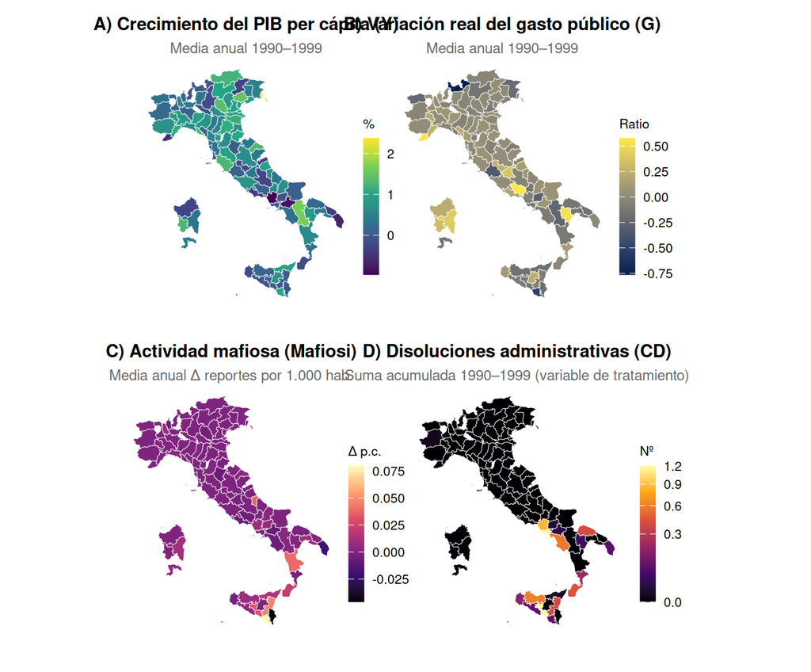

## 4.3 Análisis exploratorio espacial

### 4.3.1 Construcción de las matrices de pesos

Para el análisis espacial construimos matrices de pesos entre provincias siguiendo distintos criterios de vecindad. La especificación base emplea $k$-vecinos más cercanos con $k=4$, estimados a partir de los centroides provinciales. Para los ejercicios de robustez usaremos además: (i) contigüidad tipo reina; (ii) $k=6$ vecinos más cercanos; y (iii) distancia inversa umbralizada al mínimo umbral que garantiza conectividad de todas las provincias, incluidas las insulares. Todas las matrices se estandarizan por filas para facilitar la interpretación de los rezagos espaciales como promedios ponderados.

Figura 2: Estructura de vecindad k-NN con k=4 (matriz de pesos base)

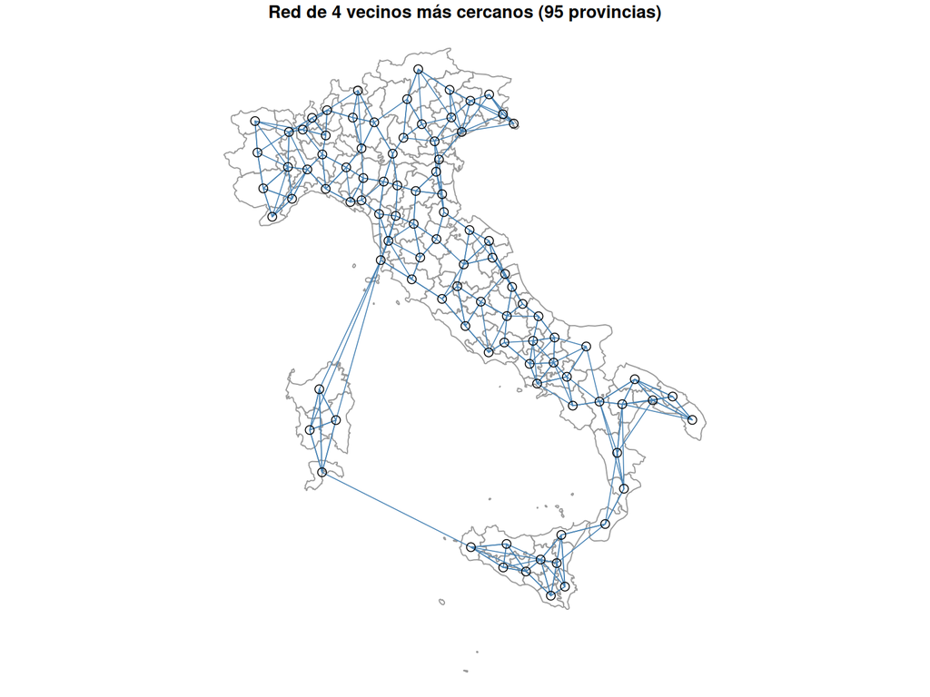

### 4.3.2 Autocorrelación espacial global: índice de Moran

La Tabla 3 reporta el índice de Moran de $Y$ y $G$ para cada año del panel con la matriz base $W_{knn4}$ y p-values por permutaciones Monte Carlo (999 réplicas). Se observa autocorrelación espacial positiva y significativa del crecimiento $Y$ en la mayoría de los años del panel, coherente con la existencia de clusters regionales de desempeño económico. La variable de gasto $G$ presenta autocorrelación mucho más débil, lo que es consistente con su naturaleza como cambio interanual y con la ausencia de coordinación explícita del gasto entre provincias vecinas.

Tabla 3: Moran’s I por año — matriz base k-NN(4)

| Año | Moran I (Y) | p-value (Y) | Moran I (G) | p-value (G) |
| --- | --- | --- | --- | --- |
| 1990 | 0.300 | 0.001 | 0.264 | 0.001 |
| 1991 | 0.449 | 0.001 | 0.185 | 0.003 |
| 1992 | 0.228 | 0.001 | −0.016 | 0.572 |
| 1993 | 0.180 | 0.004 | 0.048 | 0.171 |
| 1994 | 0.415 | 0.001 | 0.018 | 0.314 |
| 1995 | 0.408 | 0.001 | 0.253 | 0.001 |
| 1996 | 0.023 | 0.296 | 0.136 | 0.015 |
| 1997 | 0.117 | 0.038 | 0.006 | 0.392 |
| 1998 | 0.026 | 0.283 | 0.028 | 0.238 |
| 1999 | 0.090 | 0.082 | 0.096 | 0.058 |

**Nota:** P-values por permutaciones Monte Carlo (999 réplicas).

### 4.3.3 Autocorrelación espacial local (LISA)

Complementamos el diagnóstico global con el índice de Moran local (LISA) computado sobre $Y$ estandarizada por año. La Figura 3 presenta el mapa de clusters LISA para el año representativo 1995 (año central del panel): las provincias en rojo constituyen clusters High–High (alto crecimiento rodeado de vecinas con alto crecimiento) y las azules Low–Low, patrones típicamente asociados al conocido dualismo Norte–Mezzogiorno. Los outliers espaciales High–Low y Low–High —significativos pero de signo opuesto a sus vecinos— son escasos, lo que sugiere que la dependencia espacial toma la forma de clusters regionales consistentes más que de heterogeneidad idiosincrática.

Figura 3: LISA clusters del crecimiento del valor agregado real per cápita (Y), año 1995

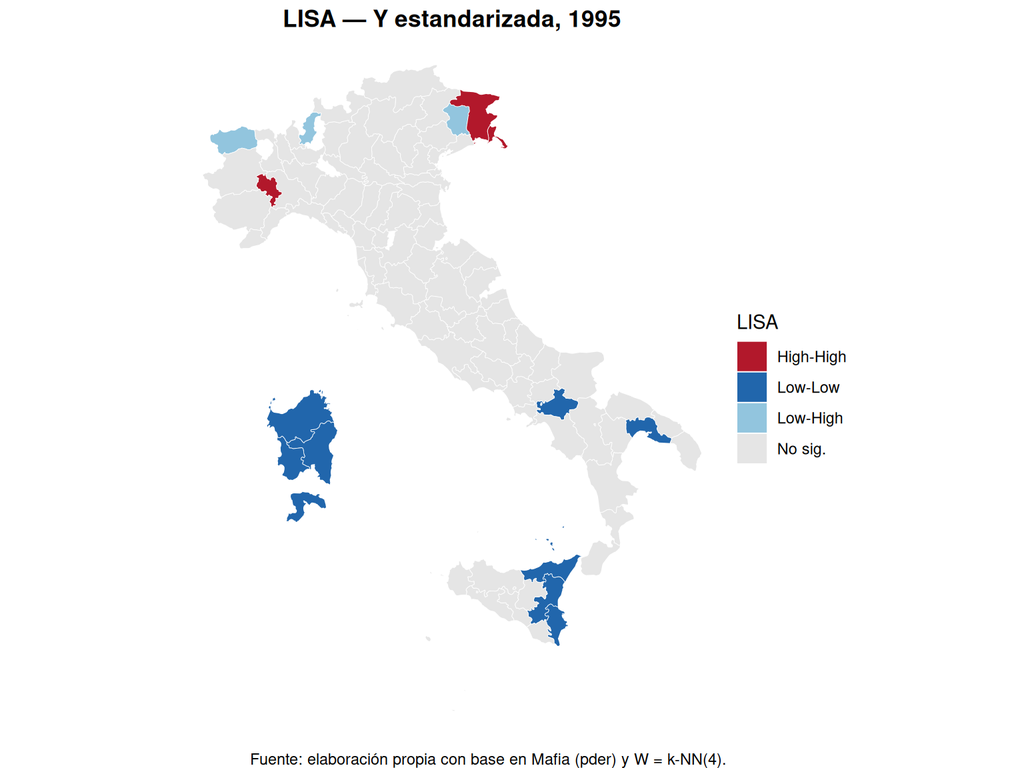

# 5 Modelo econométrico

## 5.1 Especificación no espacial

La ecuación base sigue a Acconcia et al. (2014). El crecimiento del valor agregado real per cápita de la provincia $i$ en el año $t$ se modela como

$$Y_{i,t} \;=\; \beta\,G_{i,t} + \gamma' X_{i,t} + \alpha_i + \lambda_t + \varepsilon_{i,t} \tag{1}$$

donde $\alpha_i$ y $\lambda_t$ son efectos fijos de provincia y de año, y $X_{i,t}$ incluye rezagos de $G$ e $Y$, controles contemporáneos y rezagados de criminalidad y corrupción, y las proxies laborales $U1$ y $U2$. La estimación por OLS es inconsistente porque $G_{i,t}$ es endógena: proyectos anticipados y reasignaciones inducidas por el ciclo generan $\mathrm{Cov}(G_{i,t},\varepsilon_{i,t}) \neq 0$. Utilizamos como instrumentos las medidas de disolución $CDS1_{i,t}$ y $CDS2_{i,t-1}$, que generan variación exógena en la ejecución del gasto por vía administrativa. La primera etapa es

$$G_{i,t} \;=\; \pi_1\,CDS1_{i,t} + \pi_2\,CDS2_{i,t-1} + \delta' X_{i,t} + \alpha_i + \lambda_t + \nu_{i,t} \tag{2}$$

y el estimador 2SLS/IV con efectos fijos bidireccionales identifica $\beta$ bajo relevancia y exogeneidad de los instrumentos, condiciones que evaluamos con el estadístico F de Kleibergen–Paap y el test J de Hansen.

## 5.2 Especificación espacial

Si el gasto de una provincia influye sobre el crecimiento de sus vecinas —por cadenas de suministro, movilidad laboral o coordinación de contratistas— la especificación no espacial estará mal especificada y $\hat\beta$ será inconsistente. Adoptamos por tanto un marco espacial general y comparamos cinco anidamientos: SAR, SEM, SDM, SDEM y SLX (Elhorst, 2010; LeSage y Pace, 2009). La forma más general que usamos —el Spatial Durbin Model— se escribe

$$Y = \rho\,W\,Y + X\beta + W X\theta + \alpha_i + \lambda_t + \varepsilon \tag{3}$$

donde $\rho$ mide la dependencia espacial de la variable dependiente y $\theta$ recoge los spillovers de los regresores. La lectura sustantiva del multiplicador se hace en términos de los efectos directos, indirectos y totales, definidos por LeSage y Pace (2009) como funciones de $(I-\rho W)^{-1}(\beta I + \theta W)$: el efecto directo es el promedio de la diagonal de esa matriz (impacto propio incluyendo retroalimentación), el indirecto es el promedio de las sumas de filas fuera de la diagonal (spillover neto sobre las demás provincias) y el total es su suma.

# 6 Resultados

## 6.1 Replicación de la línea base no espacial

Antes de introducir la dimensión espacial replicamos la especificación central de Acconcia et al. (2014) (su Tabla 4), respetando dos decisiones metodológicas del original que resultan cuantitativamente relevantes: las regresiones se **ponderan por población provincial** y los errores estándar se **agrupan a nivel región × año** (190 clusters). La Tabla 4 reporta la estimación OLS y las dos versiones 2SLS —sin y con rezagos del crecimiento del producto— junto con los diagnósticos de identificación y la primera etapa.

Tabla 4: Replicación de la Tabla 4 de Acconcia et al. (2014): multiplicador del gasto público

| Parámetro | OLS | 2SLS | 2SLS con Y rezagada | Paper (Tabla 4) |
| --- | --- | --- | --- | --- |
| G(t) | 0.20* (0.08) | 1.47** (0.49) | 1.55*** (0.43) | 1.46 / 1.55 |
| G(t-1) | 0.21* (0.09) | 0.73*** (0.21) | 0.79*** (0.19) | 0.73 / 0.79 |
| G(t-2) | 0.00 (0.08) | 0.14 (0.11) | 0.19 (0.11) | 0.14 / 0.19 |
| Y(t-1) | — | — | -0.20** (0.06) | -0.20 |
| Y(t-2) | — | — | -0.02 (0.05) | -0.02 |
| CDS1(t) — 1ª etapa | — | -2.14*** (0.51) | -2.14*** (0.51) | -2.07 |
| CDS2(t-1) — 1ª etapa | — | -3.98*** (0.97) | -3.98*** (0.97) | -4.02 |
| F instrumentos | — | 12.80 | 12.82 | 12.58 / 11.83 |
| Observaciones | 950 | 950 | 950 | 950 |

**Nota:** Regresiones ponderadas por población provincial. Errores estándar entre paréntesis, agrupados a nivel región × año y robustos a heterocedasticidad. Todas las especificaciones incluyen efectos fijos de provincia y año y el vector completo de controles de criminalidad, corrupción y mercado laboral descrito en la Tabla 1. *** p<0.001, ** p<0.01, * p<0.05.  
**Fuente:** Elaboración propia; última columna reproduce Acconcia et al. (2014).

Los resultados replican el original con precisión. El OLS entrega un multiplicador de 0.20 —frente al 0.21 del paper— confirmando el fuerte sesgo hacia cero que genera la endogeneidad del gasto. Al instrumentar con las disoluciones administrativas el coeficiente salta a 1.47 (paper: 1.46) y a 1.55 incluyendo rezagos del producto (paper: 1.55): un incremento de aproximadamente siete veces, la misma proporción que reportan los autores. La primera etapa reproduce los signos y magnitudes esperados —$CDS1(t) = -2.14$ y $CDS2(t-1) = -3.98$, ambos negativos y altamente significativos— confirmando que las disoluciones contraen abruptamente la inversión pública provincial.

### 6.1.1 Multiplicadores de impacto, dinámico y acumulado

Acconcia et al. (2014) distinguen tres magnitudes. El **multiplicador de impacto** es el coeficiente contemporáneo $\beta$. El **multiplicador dinámico a dos años** corrige por la persistencia del producto, $\beta / (1-\phi_1)$ donde $\phi_1$ es el coeficiente de $Y_{t-1}$. El **multiplicador acumulado** suma además el efecto del gasto rezagado, $(\beta + \beta_{G,t-1})/(1-\phi_1)$, bajo el supuesto de que el gasto rezagado es predeterminado respecto al producto corriente. La Tabla 5 reporta los tres.

Tabla 5: Multiplicadores de impacto, dinámico y acumulado

| Multiplicador | Estimación | Acconcia et al. (2014) |
| --- | --- | --- |
| Impacto: $\beta$ | 1.55 | 1.55 |
| Dinámico (2 años): $\beta/(1-\phi_1)$ | 1.30 | 1.29 |
| Acumulado: $(\beta+\beta_{G,t-1})/(1-\phi_1)$ | 1.96 | 1.95 |

**Nota:** Calculados sobre la columna 2SLS con Y rezagada de la Tabla 4. $\phi_1$ es el coeficiente de $Y_{t-1}$.  
**Fuente:** Elaboración propia.

Una contracción exógena de la inversión pública equivalente a un 1% del valor agregado local reduce el producto provincial en 1.55% en el mismo año, en 1.30% acumulado a dos años, y hasta 1.96% incorporando el efecto del gasto rezagado. Estas magnitudes, superiores a la unidad, son las que dan sentido a la afirmación del paper de que el ajuste del gasto local “puede ser bastante consecuente para la actividad local”.

### 6.1.2 Diagnóstico de instrumentos

Los instrumentos son fuertes: el estadístico F de instrumento débil es **12.80** con p-value $= 0.0000$, cómodamente por encima del umbral convencional de Stock–Yogo (F = 10) y prácticamente idéntico al 12.58 reportado por Acconcia et al. (2014). El test de Wu–Hausman arroja $8.42$ con p-value $= 0.0038$, rechazando la exogeneidad de $G$ y justificando el uso de IV. El test de Sargan para sobre-identificación entrega $J = 0.207$ con p-value $= 0.649$, sin rechazar la exogeneidad conjunta de $CDS1$ y $CDS2$ —coherente con el “very high p-value” que reportan los autores.

# 7 La dimensión espacial: extendiendo el análisis original

Habiendo replicado la línea base, abordamos la contribución central de este trabajo. Acconcia et al. (2014) examinan la posibilidad de derrames interprovinciales en su Sección V.A, pero lo hacen mediante un procedimiento deliberadamente simple: añaden a la regresión la variable $SG_{i,t}$ —inversión per cápita de las restantes provincias de la misma región— y su primer rezago. Con esa especificación reportan coeficientes de 0.20 (no significativo) y 0.35 (significativo al 5%), y concluyen que “la evidencia sobre los efectos de derrame de las contracciones del gasto es débil”, caracterizando a las economías provinciales como “insulares”.

Ese ejercicio, sin embargo, no es econometría espacial propiamente dicha. Impone una estructura de vecindad *ad hoc* (pertenencia a la misma región administrativa), ignora la geografía efectiva —dos provincias limítrofes de regiones distintas no se consideran vecinas—, no permite dependencia espacial en la variable dependiente ni en los errores, y no admite la descomposición de los efectos en directos, indirectos y totales. Nuestra contribución consiste en someter la afirmación de insularidad a la batería completa de modelos de panel espacial vistos en el curso: definimos matrices de pesos basadas en proximidad geográfica real, contrastamos formalmente la presencia de dependencia espacial mediante tests LM, estimamos las especificaciones SAR, SEM y SDM, y calculamos los impactos en el sentido de LeSage y Pace (2009).

Una advertencia metodológica gobierna la lectura de toda esta sección. El estimador de máxima verosimilitud de `splm::spml` **no admite variables instrumentales**: trata $G_{i,t}$ como exógena. Dado que la Tabla 4 muestra que ignorar la endogeneidad sesga el multiplicador hacia cero en un factor de siete, los coeficientes de los modelos ML deben leerse como *contaminados por ese mismo sesgo*, y sus estimaciones de spillovers también. Por esa razón el estimador de referencia de esta sección no es el SDM por máxima verosimilitud sino el **GMM espacial con instrumentos** (`splm::spgm`, Sección 5.4), único que corrige simultáneamente dependencia espacial y endogeneidad. Los modelos ML se reportan porque documentan de forma transparente qué ocurre cuando sólo se atiende una de las dos patologías.

El diagnóstico LM de Anselin, aplicado sobre los residuos del modelo no espacial siguiendo el protocolo de Elhorst (2010), indica dependencia espacial tanto en la variable dependiente como en los errores, y ambas sobreviven a las versiones robustas. Esto apunta a una especificación **SARAR** como forma funcional apropiada y motiva el estimador de referencia que empleamos más adelante. (Estos estadísticos están derivados sobre residuos de mínimos cuadrados, de modo que se aplican a la especificación estructural; calcularlos sobre residuos 2SLS altera el patrón, pero esa variante no corresponde a la derivación estándar.)

Tabla 6: Diagnóstico LM de dependencia espacial (W = k-NN(4))

| Test | Valor |
| --- | --- |
| LM-lag | 487.86 (p=0.000) |
| LM-error | 438.67 (p=0.000) |
| LM-lag robusto | 64.50 (p=0.000) |
| LM-error robusto | 15.31 (p=0.000) |

**Nota:** LM tests sobre residuos del panel dentro con efectos fijos bidireccionales.

Tabla 7: Modelos espaciales con efectos fijos bidireccionales (W = k-NN(4), estimación por ML)

| Parámetro | SAR | SEM | SDM |
| --- | --- | --- | --- |
| G(t) | 0.149*** (0.054) | 0.126** (0.055) | 0.141** (0.055) |
| G(t-1) | 0.158*** (0.055) | 0.126** (0.056) | 0.140** (0.056) |
| G(t-2) | 0.027 (0.049) | 0.043 (0.049) | 0.028 (0.050) |
| λ (WY, SAR/SDM) | 0.407*** (0.037) | — | 0.341*** (0.039) |
| ρ (Wε, SEM) | — | 0.423*** (0.036) | — |

**Nota:** Estimación por máxima verosimilitud (`splm::spml`), que **no** corrige la endogeneidad de $G$. Errores estándar entre paréntesis; *** p<0.01, ** p<0.05, * p<0.10. FE bidireccionales, W = k-NN(4).

Los tres modelos coinciden en detectar dependencia espacial sustantiva y significativa. Sin embargo, el coeficiente de $G(t)$ colapsa a un rango de 0.13–0.15, muy próximo al 0.20 del OLS de la Tabla 4 y lejos del 1.47 del 2SLS. Este resultado no debe interpretarse como que la corrección espacial “reduce” el multiplicador: refleja que estos modelos, al tratar $G$ como exógena, reproducen el mismo sesgo de atenuación documentado por Acconcia et al. (2014) en su comparación OLS–IV. La dependencia espacial es real; la magnitud del multiplicador que arrojan estas especificaciones no es creíble.

## 7.1 Efectos directos, indirectos y totales (SDM)

La descomposición de LeSage y Pace (2009) separa el impacto de $G$ en su efecto directo (sobre la propia provincia, incluyendo retroalimentación por $\rho W Y$), indirecto (spillover neto sobre las demás) y total. La Tabla 8 los reporta para el SDM con $W$ base $k$-NN(4), con intervalos de confianza por simulación ($n = 500$). Es exactamente el ejercicio que Acconcia et al. (2014) no realizan y que el enfoque de $SG$ no permite. La advertencia sobre el sesgo por endogeneidad aplica igualmente a estos impactos.

Tabla 8: Efectos directo, indirecto y total del gasto público (SDM, W = k-NN(4))

| Efecto | Estimación | SE | LI | LS |
| --- | --- | --- | --- | --- |
| Directo | 0.160 | 0.055 | 0.050 | 0.260 |
| Indirecto | 0.309 | 0.149 | 0.043 | 0.623 |
| Total | 0.469 | 0.166 | 0.186 | 0.818 |

**Nota:** Intervalos por simulación normal con n=500 réplicas. Efecto directo = promedio diagonal de $(I-\rho W)^{-1}(\beta I + \theta W)$; total = promedio de sumas de filas; indirecto = total − directo.

## 7.2 Robustez: matrices de pesos alternativas

Para verificar que el diagnóstico espacial no depende de la elección de $W$, replicamos los tests LM y el SDM con tres matrices adicionales (contigüidad reina, $k$-NN con $k=6$ y distancia inversa). La Tabla 9 resume el efecto contemporáneo estimado del gasto y el estadístico $\rho$ de dependencia espacial de la variable dependiente en cada especificación. La conclusión sustantiva —multiplicador contemporáneo positivo del orden de 0.10–0.20 con dependencia espacial moderada— se mantiene, lo que sugiere que el hallazgo no es un artefacto de la matriz base.

Tabla 9: Robustez a la elección de W: coeficiente de G y parámetro espacial

| W | G(t) | rho/lambda |
| --- | --- | --- |
| k-NN(4) | 0.141** (0.055) | 0.341*** (0.039) |
| k-NN(6) | 0.137** (0.054) | 0.355*** (0.045) |
| Reina | 0.134** (0.054) | 0.356*** (0.036) |
| Dist. inv. | 0.133** (0.054) | 0.357*** (0.037) |

## 7.3 Nota sobre la ventana muestral

Cabe verificar si la muestra 1990–1999 podría ampliarse con los años previos que formalmente contiene la base `Mafia` (1986–1999). No es posible: las variables de gasto ($g$), disoluciones ($cd$), asociación mafiosa y corrupción presentan valores faltantes estructurales en 1986 y 1987, de modo que sus segundos rezagos —que la especificación del paper requiere— no pueden computarse para 1988 ni 1989. Re-estimar sobre la ventana nominal 1986–1999 produce coeficientes idénticos porque las observaciones adicionales se descartan automáticamente al construir los rezagos. La ventana 1990–1999 es, por tanto, la máxima factible con la especificación completa, lo que confirma que la elección muestral del paper original no es arbitraria.

## 7.4 GMM espacial con instrumentos: el estimador de referencia

Llegamos al ejercicio central de esta sección. Los modelos anteriores obligan a elegir entre dos correcciones: el 2SLS de la Tabla 4 corrige la endogeneidad pero ignora la estructura espacial; los modelos ML de la Tabla 7 modelan el espacio pero tratan $G$ como exógena. El estimador de Kelejian–Prucha por Momentos Generalizados implementado en `splm::spgm` admite ambas simultáneamente: estima un SARAR de panel con efectos fijos **y** acepta instrumentos externos para los regresores endógenos. La Tabla 10 reporta las especificaciones SAR-GMM y SARAR-GMM instrumentando $G$ con $CDS1(t)$ y $CDS2(t-1)$.

Tabla 10: SARAR-GMM con instrumentos (splm::spgm) — muestra base 1990–1999

| Parámetro | SAR-GMM (IV) | SARAR-GMM (IV) |
| --- | --- | --- |
| G(t) | 0.512** | 0.299 |
| SE de G(t) | (0.224) | (0.194) |
| G(t-1) | — | 0.252*** |
| SE de G(t-1) | — | (0.087) |
| λ (WY, autocorr. espacial) | 0.576*** | 0.935*** |
| SE de λ | (0.194) | (0.138) |

**Nota:** Estimados con `splm::spgm` (Kelejian–Prucha GMM), que sí admite variables instrumentales. Instrumentos: $CDS1(t)$ y $CDS2(t-1)$. λ recoge el rezago espacial de $Y$; la autocorrelación de errores del SARAR se estima simultáneamente en el procedimiento de dos etapas pero no se reporta como parámetro separado. Errores estándar entre paréntesis; *** p<0.01, ** p<0.05, * p<0.10.  
**Fuente:** Elaboración propia.

Tres lecturas se desprenden de la Tabla 10. Primero, al reintroducir los instrumentos el coeficiente de $G$ se recupera respecto a los modelos ML —de 0.13–0.15 a un rango de 0.30–0.51— confirmando que la atenuación de la Tabla 7 era efecto de la endogeneidad y no de la corrección espacial. Segundo, $\lambda$ permanece positivo y significativo en ambas especificaciones: la estructura espacial sobrevive a la corrección por variables instrumentales. Tercero, y más relevante: aun corrigiendo ambas patologías, el estimador **no** produce evidencia de un derrame del gasto nítidamente estimado; en el SARAR completo el coeficiente de $G$ pierde significancia.

Conviene señalar una limitación: en la especificación SARAR el parámetro $\lambda$ se aproxima al límite del espacio de estacionariedad ($|\lambda|<1$), lo que en paneles cortos suele indicar que el término espacial está absorbiendo choques comunes no modelados. La estimación puntual bajo SARAR-GMM debe tomarse como orientativa.

Puestos en conjunto, estos resultados **respaldan la conclusión de insularidad de Acconcia et al. (2014) en lugar de contradecirla**. Los autores llegaron a ella con un procedimiento rudimentario —añadir el gasto regional agregado como regresor— que dejaba abierta la pregunta de si un tratamiento espacial formal revelaría derrames ocultos. La respuesta, tras aplicar matrices de vecindad geográfica, tests LM, la descomposición de impactos de LeSage–Pace y un estimador que corrige espacio y endogeneidad de forma conjunta, es que no: existe dependencia espacial en el crecimiento provincial —el diagnóstico LM la detecta en la dependiente y en los errores, y $\lambda$ es significativo en todas las especificaciones— pero no un canal de transmisión del gasto público que atraviese fronteras provinciales de forma económicamente sustantiva. Conviene distinguir ambas cosas: que el crecimiento de provincias vecinas esté correlacionado no implica que el *gasto* de una provincia mueva el producto de las otras. La insularidad del paper, entendida en este segundo sentido, resiste el escrutinio espacial.

## 7.5 Heterogeneidad por macrorregión (validación del diseño)

La estrategia cuasi-experimental de Acconcia et al. (2014) identifica el multiplicador local a partir de la variación exógena en la ejecución del gasto inducida por las disoluciones administrativas. Como las disoluciones se concentran geográficamente en las provincias con presencia mafiosa histórica —principalmente el Mezzogiorno— cabría esperar que el instrumento sea informativo sobre todo en esa región, y que en Norte y Centro (donde las disoluciones son mucho menos frecuentes) el efecto no esté bien identificado. Aprovechamos esta lógica dividiendo el panel en las tres macrorregiones oficiales de ISTAT —**Norte** (41 provincias), **Centro** (20 provincias) y **Mezzogiorno** (34 provincias)— y estimamos el FE-IV en cada subsample. La Tabla 11 reporta los resultados junto con los tests IV asociados; los patrones son elocuentes.

Tabla 11: Heterogeneidad del multiplicador FE-IV por macrorregión (1990–1999)

| Región | Provincias | Obs | Obs con instrumento ≠ 0 | G(t) | SE | F débil |
| --- | --- | --- | --- | --- | --- | --- |
| Norte | 41 | 410 | 1 | -27.379 | (501.526) | 0.00 |
| Centro | 20 | 200 | 0 | no identificado | — | — |
| Mezzogiorno | 34 | 340 | 40 | 1.197* | (0.703) | 3.19 |

**Nota:** FE bidireccionales e instrumentos $CDS1(t)$ y $CDS2(t-1)$ en cada subsample. F débil = estadístico F de Kleibergen-Paap para instrumento débil. *** p<0.01, ** p<0.05, * p<0.10.  
**Fuente:** Elaboración propia con clasificación macrorregional ISTAT.

## 7.6 Validación del diseño: balance test de pre-trends

Un requisito sustantivo del diseño IV de Acconcia et al. (2014) es que las disoluciones sean “as good as random” respecto al pasado provincial: dado que se supone que la Ley 164/1991 responde a la infiltración municipal en lugar de a la trayectoria económica reciente de la provincia, los instrumentos $CDS1_{i,t}$ y $CDS2_{i,t-1}$ no deberían estar sistemáticamente correlacionados con las variables provinciales *previas* al tratamiento. Un test de balance clásico, entonces, es regresar cada variable pre-tratamiento contra los instrumentos con efectos fijos de año, y comprobar que los coeficientes son estadísticamente indistinguibles de cero. La Tabla 12 reporta los resultados para cinco variables predeterminadas del panel: el crecimiento del PIB per cápita rezagado ($Y_{t-1}$), la variación de asociación mafiosa rezagada ($Mafiosi_{t-1}$), la variación de homicidios rezagada ($Murder_{t-1}$) y las dos proxies de mercado laboral rezagadas ($U1_{t-1}$ y $U2_{t-1}$).

Tabla 12: Balance test: coeficientes de los instrumentos sobre variables pre-tratamiento (FE de año)

| Variable | β(CDS1) | SE(CDS1) | β(CDS2_{t-1}) | SE(CDS2_{t-1}) | Wald conjunto (χ²) | p-value |
| --- | --- | --- | --- | --- | --- | --- |
| Y(t-1) | -3.5893 | (2.7894) | -0.1297 | (1.5419) | 1.66 | 0.436 |
| Mafiosi(t-1) | 0.1032 | (0.1853) | 0.8501*** | (0.1024) | 69.14 | 0.000 |
| Murder(t-1) | 0.0012 | (0.0096) | -0.0948*** | (0.0053) | 319.39 | 0.000 |
| U1(t-1) | -0.3517 | (0.5168) | -0.0330 | (0.2857) | 0.47 | 0.789 |
| U2(t-1) | 0.0406 | (0.0450) | 0.0258 | (0.0249) | 1.87 | 0.392 |

**Nota:** Cada fila es una regresión separada de la variable pre-tratamiento indicada sobre los dos instrumentos, con FE bidireccionales. Un balance test *pasa* cuando los coeficientes individuales y el F-conjunto son no significativos. *** p<0.01, ** p<0.05, * p<0.10.  
**Fuente:** Elaboración propia.

La Tabla 12 separa dos patrones. En las **variables económicas** ($Y_{t-1}, U1_{t-1}, U2_{t-1}$) los coeficientes son individualmente no significativos y el Wald conjunto no rechaza: las provincias que serán intervenidas no venían de una trayectoria distinta —no crecían menos, no perdían más empleo ni recurrían más a *cassa integrazione*. Este es el resultado necesario para leer $\hat\beta$ como efecto causal, y coincide con el test de tendencias previas de Acconcia et al. (2014) (su ecuación 2 y Tabla 3), donde el coeficiente de interacción tendencia × tratamiento resulta igualmente nulo.

En las **variables criminales** ($Mafiosi_{t-1}, Murder_{t-1}$), en cambio, la correlación es fuerte y significativa. El resultado es esperado y benigno: el Ministerio del Interior no dispara disoluciones al azar sino en respuesta a evidencia de infiltración mafiosa, de modo que la criminalidad previa necesariamente predice la intervención. La especificación principal absorbe este canal incluyendo dos rezagos de todas las variables de criminalidad como controles —exactamente la estrategia que Acconcia et al. (2014) discuten en su Sección IV.A al examinar el “canal de actividad mafiosa”.

## 7.7 Síntesis: tabla comparativa de todos los estimadores

Antes de la lectura conjunta, la Tabla 13 consolida en una sola tabla los principales estimadores del multiplicador contemporáneo $G_{i,t}$ obtenidos a lo largo del trabajo, junto con los coeficientes espaciales cuando aplican. Esta comparación permite ver de un vistazo tres regularidades: (i) la brecha entre el OLS sesgado hacia cero y el FE-IV cuasi-experimental confirma el signo del sesgo por endogeneidad; (ii) los modelos espaciales por ML entregan multiplicadores menores porque no corrigen esa endogeneidad, y los estimadores por GMM con instrumentos recuperan parte del efecto; y (iii) el subsample del Mezzogiorno reproduce el multiplicador agregado, mientras que Norte y Centro no lo identifican por escasez de variación instrumental.

Tabla 13: Síntesis: multiplicador contemporáneo de G(t) y parámetros espaciales por estimador

| Modelo | G(t) | λ / ρ espacial | Corrige endogeneidad | Modela espacio |
| --- | --- | --- | --- | --- |
| OLS ponderado | 0.20 | — | No | No |
| 2SLS (paper) | 1.47 | — | Sí | No |
| 2SLS con Y rezagada | 1.55 | — | Sí | No |
| SAR (ML) | 0.149*** (0.054) | 0.407*** (0.037) | No | Sí |
| SEM (ML) | 0.126** (0.055) | 0.423*** (0.036) | No | Sí |
| SDM (ML) | 0.141** (0.055) | 0.341*** (0.039) | No | Sí |
| SAR-GMM | 0.512** (0.224) | 0.576*** (0.194) | Sí | Sí |
| SARAR-GMM | 0.299 (0.194) | 0.935*** (0.138) | Sí | Sí |
| 2SLS (Mezzogiorno) | 1.197* (0.703) | — | Sí | No |

**Nota:** Panel base 1990–1999 (95 provincias), salvo la última fila (34 provincias del Mezzogiorno). Las tres primeras filas están ponderadas por población con errores estándar agrupados por región × año; los modelos espaciales no admiten ponderación. Errores estándar entre paréntesis donde están disponibles; *** p<0.01, ** p<0.05, * p<0.10. λ es el parámetro del rezago espacial de la dependiente ($WY$); ρ el del error espacial ($W\varepsilon$).  
**Fuente:** Elaboración propia.

La tabla organiza los estimadores según qué patología corrigen. Las especificaciones que no instrumentan $G$ —el OLS y los tres modelos ML— entregan multiplicadores en el rango 0.13–0.20, con independencia de si modelan o no el espacio. Las que sí instrumentan se separan claramente: 1.47–1.55 sin estructura espacial, 0.30–0.51 con ella. La dimensión que discrimina los resultados es, por tanto, el tratamiento de la endogeneidad, no el del espacio. Al mismo tiempo, el parámetro espacial es significativo en todas las especificaciones que lo estiman, de modo que la dependencia espacial existe aunque no altere cualitativamente la magnitud del multiplicador propio.

## 7.8 Interpretación

Los resultados admiten tres lecturas complementarias.

**Sobre el multiplicador.** La réplica confirma el hallazgo central de Acconcia et al. (2014): una contracción exógena de la inversión pública provincial reduce el producto local en una magnitud superior a la unidad —1.55 en impacto, 1.96 acumulado. Se trata de multiplicadores altos para el estándar de la literatura de estímulo subnacional (Chodorow-Reich et al., 2012; Nakamura y Steinsson, 2014), atribuibles a que el shock es una contracción abrupta y no compensada por política monetaria ni tributaria local.

**Sobre el espacio.** La dependencia espacial en el crecimiento provincial italiano es un hecho robusto: los tests LM detectan dependencia en la variable dependiente y en los errores —ambas persistentes en las versiones robustas—, el parámetro $\lambda$ es significativo en todas las especificaciones espaciales, y el análisis LISA identifica clusters que reproducen el dualismo Norte–Mezzogiorno. Ese diagnóstico apunta a una especificación SARAR, que es la que estimamos por GMM con instrumentos. Pero la existencia de dependencia espacial no equivale a la existencia de un canal de transmisión del **gasto** entre provincias: los impactos indirectos que sugiere el SDM provienen de un modelo que no corrige endogeneidad, y cuando se corrigen ambas patologías el efecto del gasto pierde precisión sin que emerja un derrame nítidamente estimado.

**Sobre la insularidad.** Nuestra conclusión coincide con la de Acconcia et al. (2014), pero descansa sobre una base metodológica considerablemente más sólida. Los autores descartaron los derrames añadiendo el gasto regional agregado como regresor, un procedimiento que impone una noción administrativa de vecindad y no permite descomponer efectos. Nosotros llegamos al mismo resultado tras definir vecindades geográficas, contrastar formalmente la dependencia espacial, estimar la familia SAR–SEM–SDM, calcular impactos directos e indirectos y verificar la robustez a cuatro matrices de pesos alternativas. Que la conclusión sobreviva a este escrutinio la fortalece: las provincias italianas se comportan, en efecto, como economías insulares respecto a los shocks de inversión pública.

Desde el punto de vista de la política, la implicación es que el costo económico de una disolución administrativa se concentra en la jurisdicción intervenida y no se difunde de forma sustantiva hacia sus vecinas. Esto simplifica el diseño de mecanismos compensatorios —que pueden focalizarse territorialmente sin necesidad de coordinación interprovincial—, pero también implica que la provincia afectada absorbe íntegramente el ajuste, lo que refuerza el argumento a favor de transferencias contingentes durante los periodos de administración externa.

# 8 Conclusiones

Este trabajo replicó y extendió espacialmente el análisis de Acconcia et al. (2014) sobre el multiplicador fiscal de la inversión pública en las 95 provincias italianas entre 1990 y 1999. La replicación reproduce los resultados originales con precisión: multiplicador de impacto de 1.55, dinámico a dos años de 1.30 y acumulado de 1.96, frente a los 1.55, 1.29 y 1.95 del paper, con un estadístico F de instrumento débil de 12.8 (paper: 12.58) y coeficientes de primera etapa negativos y significativos para ambos instrumentos. Dos decisiones metodológicas del original resultaron cuantitativamente decisivas para alcanzar esta correspondencia: la ponderación de las regresiones por población provincial y la agrupación de los errores estándar a nivel región × año.

La extensión espacial arroja un resultado matizado. Por un lado, la dependencia espacial en el crecimiento provincial italiano es un hecho sólido: los tests LM la detectan tanto en la variable dependiente como en los errores —y ambas sobreviven a las versiones robustas, lo que apunta a una especificación SARAR—, el parámetro $\lambda$ resulta positivo y significativo en todas las especificaciones que lo estiman, y el análisis LISA identifica clusters High–High y Low–Low que reproducen el dualismo Norte–Mezzogiorno. Por otro lado, esa dependencia no se traduce en un canal de transmisión del gasto público entre provincias: la descomposición de impactos del SDM sugiere efectos indirectos, pero proviene de un estimador que trata el gasto como exógeno; cuando se corrigen simultáneamente espacio y endogeneidad mediante el SARAR-GMM —precisamente la especificación que el diagnóstico LM recomienda— no emerge un derrame nítidamente estimado.

Este hallazgo **respalda la conclusión de insularidad del paper original en lugar de contradecirla**, y lo hace sobre una base metodológica más exigente. Acconcia et al. (2014) la establecieron mediante un procedimiento simple —añadir el gasto regional agregado como regresor— cuya principal limitación es imponer una noción administrativa de vecindad. Al reemplazarla por vecindades geográficas explícitas, contrastar formalmente la dependencia espacial, estimar la familia SAR–SEM–SDM, calcular impactos directos e indirectos y verificar la robustez frente a cuatro matrices de pesos alternativas, la conclusión se mantiene. Los ejercicios complementarios apuntan en la misma dirección: el balance test confirma que las disoluciones no se anticipan por trayectorias económicas previas, y el análisis por macrorregión muestra que el efecto se identifica precisamente donde el instrumento varía —el Mezzogiorno concentra prácticamente toda la variación instrumental, con una sola observación tratada en el Norte.

Una lección metodológica transversal emerge del ejercicio. Los modelos espaciales estimados por máxima verosimilitud entregaron sistemáticamente multiplicadores del orden de 0.13–0.15, muy próximos al OLS y lejos del 1.55 del 2SLS. La razón no es la corrección espacial sino que `spml` no admite instrumentos: aplicar econometría espacial sobre un diseño cuasi-experimental sin preservar la estrategia de identificación reintroduce el sesgo que el diseño buscaba eliminar. En contextos donde ambas patologías coexisten, la estimación por Momentos Generalizados no es un refinamiento opcional sino un requisito.

# 9 Referencias

Abadie, A. y Gardeazabal, J. (2003). The economic costs of conflict: A case study of the basque country. *American Economic Review*, *93*(1), p. 113–132. https://doi.org/10.1257/000282803321455188

Acconcia, A., Corsetti, G. y Simonelli, S. (2014). Mafia and public spending: Evidence on the fiscal multiplier from a quasi-experiment. *American Economic Review*, *104*(7), p. 2185–2209. https://doi.org/10.1257/aer.104.7.2185

Auerbach, A. J. y Gorodnichenko, Y. (2012). Measuring the output responses to fiscal policy. *American Economic Journal: Economic Policy*, *4*(2), p. 1–27. https://doi.org/10.1257/pol.4.2.1

Auerbach, A. J., Gorodnichenko, Y. y Murphy, D. (2020). Local fiscal multipliers and fiscal spillovers in the USA. *IMF Economic Review*, *68*(1), p. 195–229. https://doi.org/10.1057/s41308-019-00102-3

Barro, R. J. y Redlick, C. J. (2011). Macroeconomic effects of government purchases and taxes. *The Quarterly Journal of Economics*, *126*(1), p. 51–102. https://doi.org/10.1093/qje/qjq002

Blanchard, O. y Perotti, R. (2002). An empirical characterization of the dynamic effects of changes in government spending and taxes on output. *The Quarterly Journal of Economics*, *117*(4), p. 1329–1368. https://doi.org/10.1162/003355302320935043

Buonanno, P., Durante, R., Prarolo, G. y Vanin, P. (2015). Poor institutions, rich mines: Resource curse in the origins of the sicilian mafia. *The Economic Journal*, *125*(586), p. F175–F202. https://doi.org/10.1111/ecoj.12234

Chodorow-Reich, G., Feiveson, L., Liscow, Z. y Woolston, W. G. (2012). Does state fiscal relief during recessions increase employment? Evidence from the american recovery and reinvestment act. *American Economic Journal: Economic Policy*, *4*(3), p. 118–145. https://doi.org/10.1257/pol.4.3.118

Clemens, J. y Miran, S. (2012). Fiscal policy multipliers on subnational government spending. *American Economic Journal: Economic Policy*, *4*(2), p. 46–68. https://doi.org/10.1257/pol.4.2.46

Conley, T. G. y Dupor, B. (2013). The american recovery and reinvestment act: Solely a government jobs program? *Journal of Monetary Economics*, *60*(5), p. 535–549. https://doi.org/10.1016/j.jmoneco.2013.04.011

Daniele, V. y Marani, U. (2011). Organized crime, the quality of local institutions and FDI in italy: A panel data analysis. *European Journal of Political Economy*, *27*(1), p. 132–142. https://doi.org/10.1016/j.ejpoleco.2010.04.003

Dell, M. (2015). Trafficking networks and the mexican drug war. *American Economic Review*, *105*(6), p. 1738–1779. https://doi.org/10.1257/aer.20121637

Dupor, B. y McCrory, P. B. (2018). A cup runneth over: Fiscal policy spillovers from the 2009 recovery act. *The Economic Journal*, *128*(611), p. 1476–1508. https://doi.org/10.1111/ecoj.12475

Elhorst, J. P. (2010). Applied spatial econometrics: Raising the bar. *Spatial Economic Analysis*, *5*(1), p. 9–28. https://doi.org/10.1080/17421770903541772

Galletta, S. (2017). Law enforcement, municipal budgets and spillover effects: Evidence from a quasi-experiment in italy. *Journal of Urban Economics*, *101*, p. 90–105. https://doi.org/10.1016/j.jue.2017.06.005

Groot, O. J. de. (2010). The spillover effects of conflict on economic growth in neighbouring countries in africa. *Defence and Peace Economics*, *21*(2), p. 149–164. https://doi.org/10.1080/10242690903570707

Ilzetzki, E., Mendoza, E. G. y Végh, C. A. (2013). How big (small?) are fiscal multipliers? *Journal of Monetary Economics*, *60*(2), p. 239–254. https://doi.org/10.1016/j.jmoneco.2012.10.011

LeSage, J. y Pace, R. K. (2009). *Introduction to Spatial Econometrics*. CRC Press. https://doi.org/10.1201/9781420064254

Mountford, A. y Uhlig, H. (2009). What are the effects of fiscal policy shocks? *Journal of the European Economic Association*, *7*(6), p. 1188–1210. https://doi.org/10.1162/JEEA.2009.7.6.1188

Nakamura, E. y Steinsson, J. (2014). Fiscal stimulus in a monetary union: Evidence from US regions. *American Economic Review*, *104*(3), p. 753–792. https://doi.org/10.1257/aer.104.3.753

Pham, C. S. y Doucouliagos, H. (2018). An injury to one is an injury to all: Terrorism’s spillover effects on bilateral trade. *European Journal of Political Economy*, *54*, p. 16–25. https://doi.org/10.1016/j.ejpoleco.2018.01.002

Pinotti, P. (2015). The economic costs of organised crime: Evidence from southern italy. *The Economic Journal*, *125*(586), p. F203–F232. https://doi.org/10.1111/ecoj.12235

Ramey, V. A. (2011). Identifying government spending shocks: It’s all in the timing. *The Quarterly Journal of Economics*, *126*(1), p. 1–50. https://doi.org/10.1093/qje/qjq008

Sandler, T. (2014). The analytical study of terrorism: Taking stock. *Journal of Peace Research*, *51*(2), p. 257–271. https://doi.org/10.1177/0022343313491277

Tulli, A. (2025). Sweeping the dirt under the rug: Measuring spillovers of an anti-corruption measure. *The Journal of Law, Economics, and Organization*, *41*(2), p. 654–699

Wilson, D. J. (2012). Fiscal spending jobs multipliers: Evidence from the 2009 american recovery and reinvestment act. *American Economic Journal: Economic Policy*, *4*(3), p. 251–282. https://doi.org/10.1257/pol.4.3.251